# Homework 1

Frank Marino

2026-01-16

## Load Libraries

```r
# Load any R Packages you may need
require(dplyr)
require(ggplot2)
```

## Exercise 1

The state of Arizona records the number of automobile deaths two years ago in each of the state’s 14 counties:

- 30, 15, 183, 9, 7, 39, 28, 30, 76, 13, 21, 18, 323, 3

### (a)

Using R, enter these data into a variable called `autodths`.

```r
# Type your code here
autodths <- data.frame(
  county = c(1, 2, 3, 4, 5, 6, 7, 8, 9, 10, 11, 12, 13, 14),
  county_death = c(30, 15, 183, 9, 7, 39, 28, 30, 76, 13, 21, 18, 323, 3)
)
```

### (b)

What is the mean number of deaths per county?

```r
# Type your code here
mean_death <- mean(autodths$county_death)
```

The mean number of deaths per county is 56.8.

### (c)

What is the median number of deaths per county?

```r
# Type your code here
median_death <- median(autodths$county_death)
```

The median number of deaths per county is 24.5.

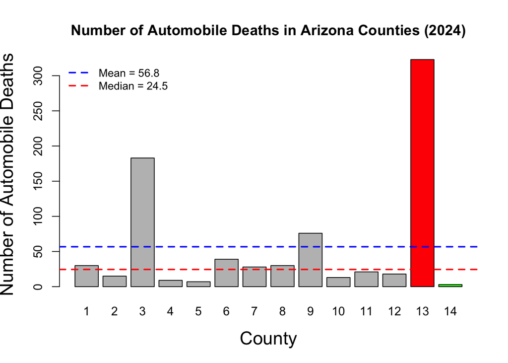

```r
colors <- ifelse(autodths$county_death == max(autodths$county_death),
                 "red",
                 ifelse(autodths$county_death == min(autodths$county_death),
                        "green",
                        "grey"))

chart <- barplot(autodths$county_death,
        names.arg = autodths$county,
        xlab = "County",
        ylab = "Number of Automobile Deaths",
        main = "Number of Automobile Deaths in Arizona Counties (2024)",
        col = colors,
        cex.lab = 1.5
        )
abline(h = mean(autodths$county_death),
                      col = "blue",
                      lty = 2,
                      lwd = 2
                      )
abline(h = median(autodths$county_death),
       col = "red",
       lty = 2,
       lwd = 2
       )
legend("topleft",
       legend = c(paste("Mean =", round(mean_death, 1)),
                  paste("Median =", round(median_death, 2))),
       col = c("blue", "red"),
       lty = c(2, 2),      # Both dashed
       lwd = c(2, 2),      # Both width 2
       bty = "n",          # No box
       cex = 0.9)
```

## Exercise 2

In a survey of students several years ago, one question asked for each student’s political preference (Democrat (D), Independent (I), or Republican (R)). Here are the 14 responses:

- D, I, I, D, I, D, I, I, I, D, I, R, D, D

### (a)

Using R, enter these data into a variable called `polpref`.

```r
# Type your code here
polpref <- data.frame(
  preference = c("D", "I", "I", "D", "I", "D", "I", "I", "I", "D", "I", "R", "D", "D")
)
```

### (b)

Use the `tally()` function to determine the most popular choice of political preference.

```r
# Type your code here
polpref <- polpref %>%
  group_by(preference) %>%
  tally()
polpref
```

```
## # A tibble: 3 × 2
##   preference     n
##   <chr>      <int>
## 1 D              6
## 2 I              7
## 3 R              1
```

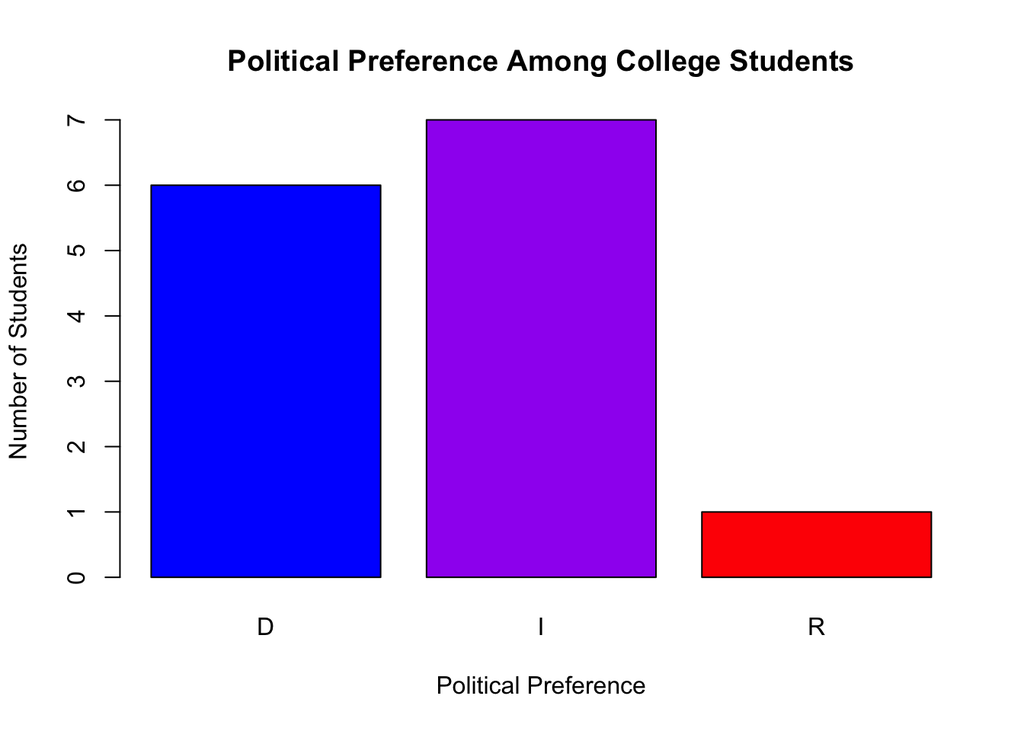

```r
colors <- ifelse(polpref$preference == "D", "blue", ifelse(polpref$preference == "I", "purple", "red"))
barplot(polpref$n,
        names.arg = polpref$preference,
        xlab = "Political Preference",
        ylab = "Number of Students",
        main = "Political Preference Among College Students",
        col = colors)
```

> The most popular choice of political preference is Independent.

## Exercise 3

### (a)

Create a Canva Presentation with two slides:

- Slide 1: Create a data visualization for the data in Exercise 1
- Slide 2: Create a data visualization for the data in Exercise 2

### (b)

[interactive chart not shown]

[Automobile Deaths in Arizon Counties (2024)](https://www.canva.com/design/DAG-sVwLV2w/6fhNqd-utjrbaLwMPo9-RA/view?utm_content=DAG-sVwLV2w&utm_campaign=designshare&utm_medium=embeds&utm_source=link) by Frank Marino

### (c)

Trouble embedding? No worries! Provide your Canva link here as a back-up

URL Link to Canva Site: [Frank Marino - Homework 1](https://www.canva.com/design/DAG-sVwLV2w/6fhNqd-utjrbaLwMPo9-RA/view)

## All done!

Knit the completed R Markdown file as a HTML document (click the “Knit” button at the top of the script editor window) and upload it to the submission portal on Canvas.